# Assignment-Czechia

Diyana Hewage-AS2019372

2022-10-07

# **COVID-19 Pandemic in Czechia**

# 1.Introduction

COVID-19 pandemic is well known global health crisis that was happening in past 3 years. it is also ongoing pandemic in all those years .According to the WHO,it caused more than 620 millions cases and 6.55 million confirmed deaths.COVID-19 caused by the SARS-CoV-2 virus,which means Severe acute respiratory syndrome Coronavirus 2.

First COVID-19 case was found in Wuhan city in China in December 2019.Most common symptoms are fever,cough,tiredness and loss of taste or smell. less common symptoms are sore throat,headache,aches and pains,diarrhoea,a rash on skin or discoloration and red or irritated eyes.

This report shows how the COVID-19 affect to the Czechia by using exploratory analysis.

## 1.1.Location of the Czechia

Czechia is locates bordered by Germany to the west, Poland to the northeast, Slovakia to the southeast and Austria to the south.

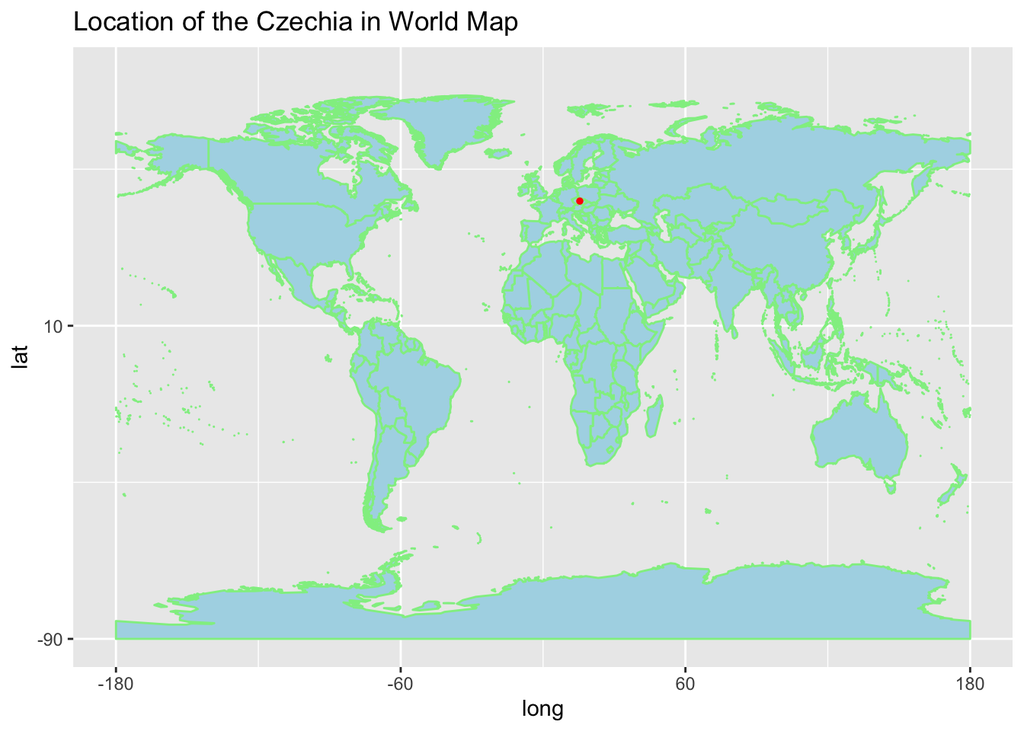

## 1.2.Climate Condition in Czechia

Czechia is lie in the temperate climate zone, it is characterized by mild and humid summer with occasional hot spells,cold,cloudy and humid winters.In the month of July , weather and climate is maximum, and in the month of February it is at its lowest.

## 1.3.Lockdown status of the Czechia and actions that were taken by the Government

First confirmed corona cases in Czechia were reported on 1st of March 2020. The government declared a state of emergency on 12th of March. The country closed its borders,baned the entry of foreigners without residence permit, on 16th of March and also issued a curfew all over the country. It has to be end on 24th of March but the curfew was extended until 30th of April and then again until 17th of May. Czechia is the first European country which make wearing the face mask mandatory from 19th of March onward.

On 1st of May 2022 , 257 covid deaths cases were confirmed. It was bit lower than to other countries. however on 17th of November 2020 , total of 6416 deaths were confirmed . In month of August 2021, Czechia has recorded the fourth highest confirmed death rate in the world.

# 2.Exploratory Data Analysis

## 2.1.All the COVID-19 Cases around the world

Table 01 : Summarised COVID cases around the world

| type | sum(cases) |
| --- | --- |
| confirmed | 542125310 |
| death | 6326030 |
| recovery | 0 |

Table 01 shows world wide COVID-19 cases.

```
        date province country     lat      long      type cases   uid iso2 iso3
1 2020-01-22  Alberta  Canada 53.9333 -116.5765 confirmed     0 12401   CA  CAN
2 2020-01-23  Alberta  Canada 53.9333 -116.5765 confirmed     0 12401   CA  CAN
3 2020-01-24  Alberta  Canada 53.9333 -116.5765 confirmed     0 12401   CA  CAN
4 2020-01-25  Alberta  Canada 53.9333 -116.5765 confirmed     0 12401   CA  CAN
5 2020-01-26  Alberta  Canada 53.9333 -116.5765 confirmed     0 12401   CA  CAN
6 2020-01-27  Alberta  Canada 53.9333 -116.5765 confirmed     0 12401   CA  CAN
  code3    combined_key population continent_name continent_code
1   124 Alberta, Canada    4413146  North America             NA
2   124 Alberta, Canada    4413146  North America             NA
3   124 Alberta, Canada    4413146  North America             NA
4   124 Alberta, Canada    4413146  North America             NA
5   124 Alberta, Canada    4413146  North America             NA
6   124 Alberta, Canada    4413146  North America             NA
```

```
             date province  country       lat     long     type cases uid iso2
742555 2022-06-18     <NA> Zimbabwe -19.01544 29.15486 recovery     0 716   ZW
742556 2022-06-19     <NA> Zimbabwe -19.01544 29.15486 recovery     0 716   ZW
742557 2022-06-20     <NA> Zimbabwe -19.01544 29.15486 recovery     0 716   ZW
742558 2022-06-21     <NA> Zimbabwe -19.01544 29.15486 recovery     0 716   ZW
742559 2022-06-22     <NA> Zimbabwe -19.01544 29.15486 recovery     0 716   ZW
742560 2022-06-23     <NA> Zimbabwe -19.01544 29.15486 recovery     0 716   ZW
       iso3 code3 combined_key population continent_name continent_code
742555  ZWE   716     Zimbabwe   14862927         Africa             AF
742556  ZWE   716     Zimbabwe   14862927         Africa             AF
742557  ZWE   716     Zimbabwe   14862927         Africa             AF
742558  ZWE   716     Zimbabwe   14862927         Africa             AF
742559  ZWE   716     Zimbabwe   14862927         Africa             AF
742560  ZWE   716     Zimbabwe   14862927         Africa             AF
```

```
  [1] "Canada"                           "United Kingdom"
  [3] "China"                            "Netherlands"
  [5] "Australia"                        "New Zealand"
  [7] "Denmark"                          "France"
  [9] "Afghanistan"                      "Albania"
 [11] "Algeria"                          "Andorra"
 [13] "Angola"                           "Antarctica"
 [15] "Antigua and Barbuda"              "Argentina"
 [17] "Armenia"                          "Austria"
 [19] "Azerbaijan"                       "Bahamas"
 [21] "Bahrain"                          "Bangladesh"
 [23] "Barbados"                         "Belarus"
 [25] "Belgium"                          "Belize"
 [27] "Benin"                            "Bhutan"
 [29] "Bolivia"                          "Bosnia and Herzegovina"
```

[output cut: 85 more lines]

Here 187 countries are available.

## 2.2.COVID-19 Data of Czechia

```
      date              province           country               lat
 Min.   :2020-01-22   Length:2652        Length:2652        Min.   :49.82
 1st Qu.:2020-08-29   Class :character   Class :character   1st Qu.:49.82
 Median :2021-04-07   Mode  :character   Mode  :character   Median :49.82
 Mean   :2021-04-07                                         Mean   :49.82
 3rd Qu.:2021-11-14                                         3rd Qu.:49.82
 Max.   :2022-06-23                                         Max.   :49.82
      long           type               cases                 uid
 Min.   :15.47   Length:2652        Min.   :-1641321.0   Min.   :203
 1st Qu.:15.47   Class :character   1st Qu.:       1.0   1st Qu.:203
 Median :15.47   Mode  :character   Median :      79.5   Median :203
 Mean   :15.47                      Mean   :    1496.4   Mean   :203
 3rd Qu.:15.47                      3rd Qu.:     895.2   3rd Qu.:203
 Max.   :15.47                      Max.   :   57378.0   Max.   :203
     iso2               iso3               code3     combined_key
 Length:2652        Length:2652        Min.   :203   Length:2652
 Class :character   Class :character   1st Qu.:203   Class :character
 Mode  :character   Mode  :character   Median :203   Mode  :character
                                       Mean   :203
                                       3rd Qu.:203
                                       Max.   :203
   population       continent_name     continent_code
 Min.   :10708982   Length:2652        Length:2652
 1st Qu.:10708982   Class :character   Class :character
 Median :10708982   Mode  :character   Mode  :character
 Mean   :10708982
 3rd Qu.:10708982
 Max.   :10708982
```

## 2.3.Confirmed COVID-19 cases in Czechia

Table 02 shows the confirmed COVID-19 cases in Czechia.

Table 02:confirmed cases of COVID-19 in Czechia

| date | province | country | lat | long | type | cases | uid | iso2 | iso3 | code3 | combined_key | population | continent_name | continent_code |
| --- | --- | --- | --- | --- | --- | --- | --- | --- | --- | --- | --- | --- | --- | --- |
| 2020-01-22 | NA | Czechia | 49.8175 | 15.473 | confirmed | 0 | 203 | CZ | CZE | 203 | Czechia | 10708982 | Europe | EU |
| 2020-01-23 | NA | Czechia | 49.8175 | 15.473 | confirmed | 0 | 203 | CZ | CZE | 203 | Czechia | 10708982 | Europe | EU |
| 2020-01-24 | NA | Czechia | 49.8175 | 15.473 | confirmed | 0 | 203 | CZ | CZE | 203 | Czechia | 10708982 | Europe | EU |
| 2020-01-25 | NA | Czechia | 49.8175 | 15.473 | confirmed | 0 | 203 | CZ | CZE | 203 | Czechia | 10708982 | Europe | EU |
| 2020-01-26 | NA | Czechia | 49.8175 | 15.473 | confirmed | 0 | 203 | CZ | CZE | 203 | Czechia | 10708982 | Europe | EU |
| 2020-01-27 | NA | Czechia | 49.8175 | 15.473 | confirmed | 0 | 203 | CZ | CZE | 203 | Czechia | 10708982 | Europe | EU |

##### Total confirmed covid cases in Czechia

```
[1] 3928025
```

Total of 3928025 cases were confirmed in Czechia.

#### Plot of Confirmed COVID-19 cases in Czechia

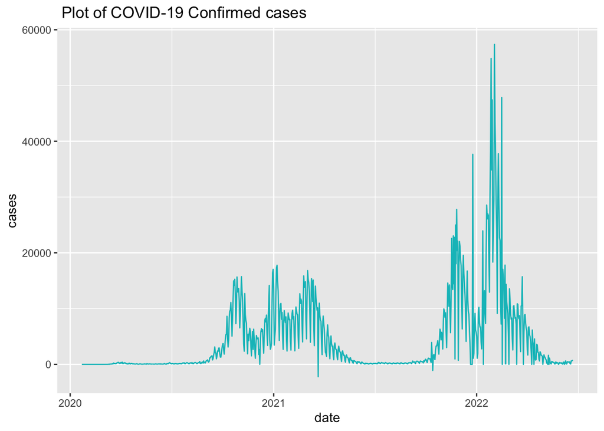

Above graph shows the covid-19 confirmed cases in Czechia.

According to the graph, number of confirmed cases were increased in year 2022.In the year of 2022, number of confirmed cases came to its peak and that is more than 50000. then again number of confirmed cases were decreasing gradually.

## 2.4.Death cases because of COVID-19 in Czechia

Table 03:Death cases due to COVID-19

| date | province | country | lat | long | type | cases | uid | iso2 | iso3 | code3 | combined_key | population | continent_name | continent_code |
| --- | --- | --- | --- | --- | --- | --- | --- | --- | --- | --- | --- | --- | --- | --- |
| 2020-01-22 | NA | Czechia | 49.8175 | 15.473 | death | 0 | 203 | CZ | CZE | 203 | Czechia | 10708982 | Europe | EU |
| 2020-01-23 | NA | Czechia | 49.8175 | 15.473 | death | 0 | 203 | CZ | CZE | 203 | Czechia | 10708982 | Europe | EU |
| 2020-01-24 | NA | Czechia | 49.8175 | 15.473 | death | 0 | 203 | CZ | CZE | 203 | Czechia | 10708982 | Europe | EU |
| 2020-01-25 | NA | Czechia | 49.8175 | 15.473 | death | 0 | 203 | CZ | CZE | 203 | Czechia | 10708982 | Europe | EU |
| 2020-01-26 | NA | Czechia | 49.8175 | 15.473 | death | 0 | 203 | CZ | CZE | 203 | Czechia | 10708982 | Europe | EU |
| 2020-01-27 | NA | Czechia | 49.8175 | 15.473 | death | 0 | 203 | CZ | CZE | 203 | Czechia | 10708982 | Europe | EU |

#### Total Death cases in Czechia

```
[1] 40312
```

#### Plot of Death cases in Czechia

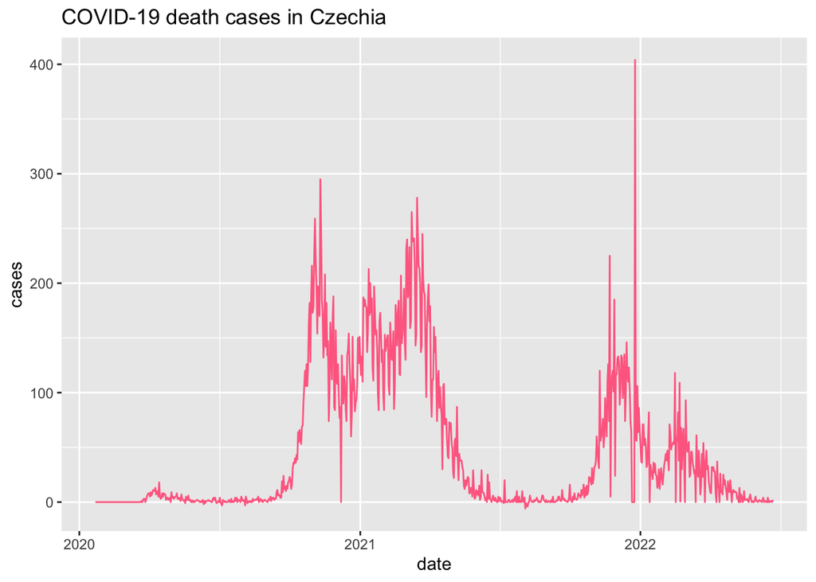

As we can see in the graph,deaths due to the COVID-19 is gradually increased in the year 2021 and again decreased.but again in year 2022 number of deaths were increased and peak value of deaths were reported in December 2021.peak value of the death cases were more than 400. according to the graph we can see that number of death cases were decreasing gradually and it is near to the zero in the year 2022.

## 2.5.Recovered COVID-19 cases in Czechia

```
        date province country     lat   long     type cases uid iso2 iso3 code3
1 2020-01-22     <NA> Czechia 49.8175 15.473 recovery     0 203   CZ  CZE   203
2 2020-01-23     <NA> Czechia 49.8175 15.473 recovery     0 203   CZ  CZE   203
3 2020-01-24     <NA> Czechia 49.8175 15.473 recovery     0 203   CZ  CZE   203
4 2020-01-25     <NA> Czechia 49.8175 15.473 recovery     0 203   CZ  CZE   203
5 2020-01-26     <NA> Czechia 49.8175 15.473 recovery     0 203   CZ  CZE   203
6 2020-01-27     <NA> Czechia 49.8175 15.473 recovery     0 203   CZ  CZE   203
  combined_key population continent_name continent_code
1      Czechia   10708982         Europe             EU
2      Czechia   10708982         Europe             EU
3      Czechia   10708982         Europe             EU
4      Czechia   10708982         Europe             EU
5      Czechia   10708982         Europe             EU
6      Czechia   10708982         Europe             EU
```

#### Plot of COVID-19 Recoveries in Czechia

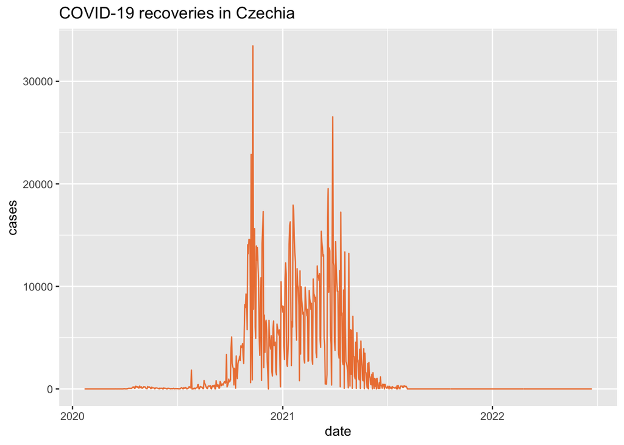

## 2.6. Active COVID-19 cases in Czechia

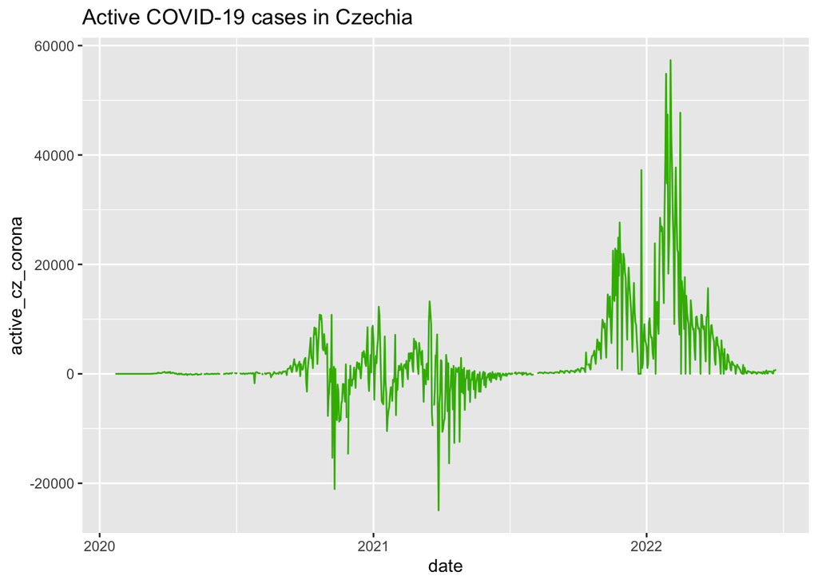

As we can see in the graph ,highest number of active cases were recorded in year 2022. that is more than 50000.

#### Plot of Active COVID-19 cases in Czechia

```
        date province country     lat   long      type cases uid iso2 iso3
1 2020-01-22     <NA> Czechia 49.8175 15.473 confirmed     0 203   CZ  CZE
2 2020-01-23     <NA> Czechia 49.8175 15.473 confirmed     0 203   CZ  CZE
3 2020-01-24     <NA> Czechia 49.8175 15.473 confirmed     0 203   CZ  CZE
4 2020-01-25     <NA> Czechia 49.8175 15.473 confirmed     0 203   CZ  CZE
5 2020-01-26     <NA> Czechia 49.8175 15.473 confirmed     0 203   CZ  CZE
6 2020-01-27     <NA> Czechia 49.8175 15.473 confirmed     0 203   CZ  CZE
  code3 combined_key population continent_name continent_code
1   203      Czechia   10708982         Europe             EU
2   203      Czechia   10708982         Europe             EU
3   203      Czechia   10708982         Europe             EU
4   203      Czechia   10708982         Europe             EU
5   203      Czechia   10708982         Europe             EU
6   203      Czechia   10708982         Europe             EU
```

[figure not shown]

#### COVID-19 cases by Type

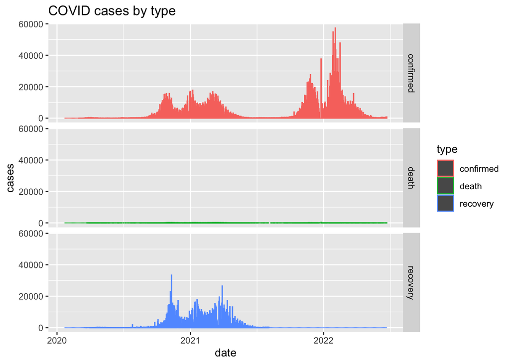

This plot shows all the distribution of recoveries, confirmed and death cases of Czechia in a one frame. According to the graph we can see that confirmed cases are higher than recovered cases.death cases are very lower than to confirmed and recovered cases.